# Demonetization Sentiment Analysis: Event Study using Twitter Data

### Sentiment Wave: Feedback over Time

Distirbution of Postive, Negative and Neutral feedback of users. Notice the overall spike and movement of distribution along specific days and time intervals. To explore this further, see the next chart.

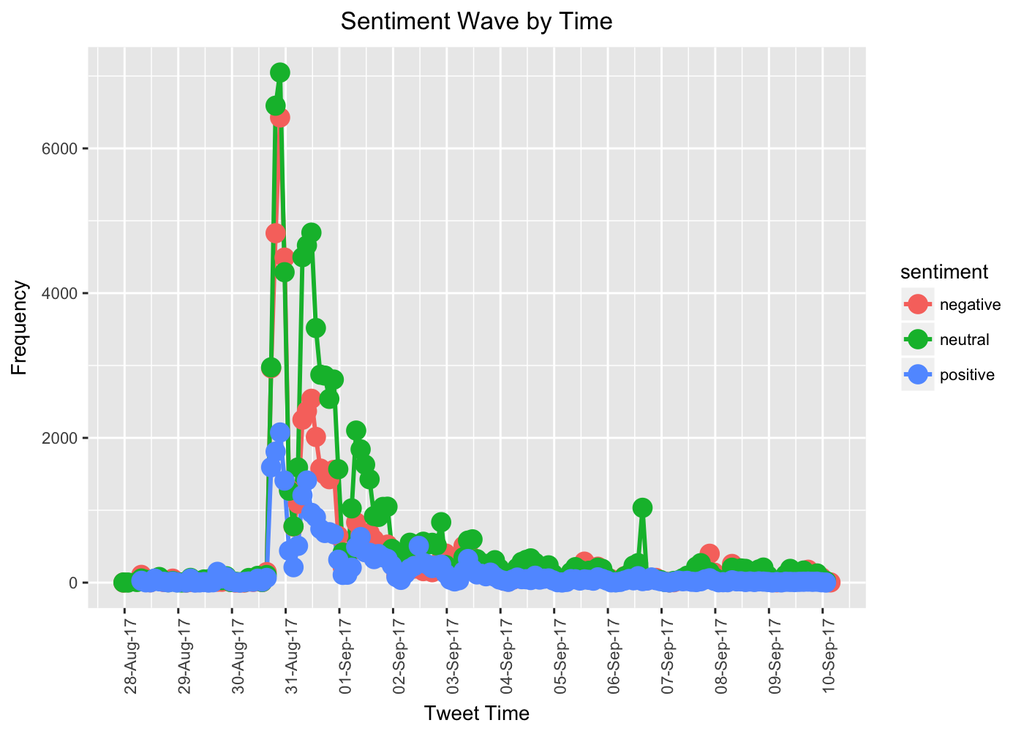

### Event Study for a specified period: 30th August to 2nd September, 2017

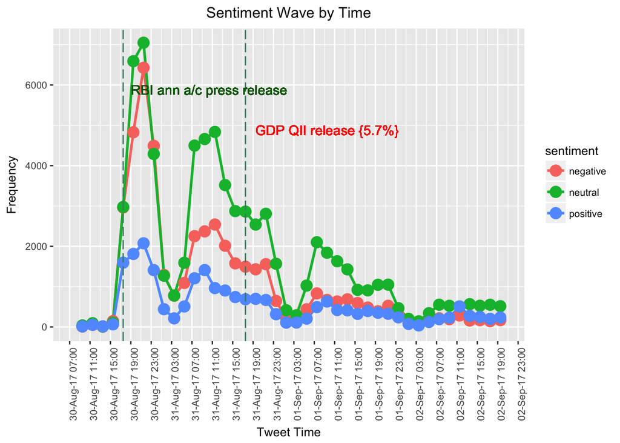

### Spectrum of Sentiment Response on Demonetization

The tweets have been scored over a spectrum of positive, negative and neutral sentiments. Further they have been sub-classified by the fervor/intensity of a particular emotion. The following chart displays a distrbution for the same.

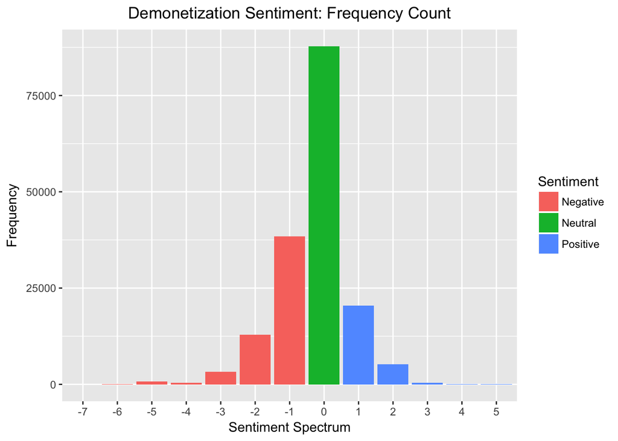

### Setting-up Twitter connection: ROuth Authentication

R can extract tweets by setting up a connection Twitter his function wraps the OAuth authentication handshake functions from the httr package for a twitteR session. Details for the process are: https://www.rdocumentation.org/packages/twitteR/versions/1.1.9/topics/setup_twitter_oauth The code here currently uses Authentication Credentials from a pre- established connection (to save processing time)

```
pt <- "/Users/parthkhare/Desktop/TwitterSurvey"
load(paste0(pt,"/twit_cred.RData"))
setup_twitter_oauth(consumerKey, consumerSecret, access_token, access_token_secret)

# Extract Tweets from Twitter
dem <- searchTwitter("#demonetisation", n = 85000)
# Convert the Tweet List to Data Frame
dm <- do.call("rbind", lapply(dem, as.data.frame))
```

### Text Cleaning and Corpus Generation: R Codes

```
load(file = "/Users/parthkhare/Desktop/TwitterSurvey/Demonetisation/Event/Dem85_2sep.RData")
# Convert tweets to data frame
# ---------------
dm <- dm1
dm$tx <- dm$text

# Text Transformations
# ---------------
# Remove Re-Tweets
dm$tx <- gsub("(RT|via)((?:\\b\\W*@\\w+)+)", "", dm$tx)
# Replace blank space (???rt???)
dm$tx <- gsub("rt", "", dm$tx)
# Replace @UserName
dm$tx <- gsub("@\\w+", "", dm$tx)
# Remove punctuation
dm$tx <- gsub("[[:punct:]]", "", dm$tx)
# Remove links
dm$tx <- gsub("http\\w+", "", dm$tx)
# Remove Special Characters
dm$tx <- gsub("[^a-zA-Z0-9 ]","",dm$tx)
# Remove blank spaces at the beginning
dm$tx <- gsub("^ ", "", dm$tx)
# Remove blank spaces at the end
dm$tx <- gsub(" $", "", dm$tx)
# Remove tabs
dm$tx <- gsub("[ |\t]{2,}", "", dm$tx)

# Corpus Generation
# ---------------
crp <- Corpus(VectorSource(dm$tx))

# Strelaization
# ---------------
# strip white space
crp <- tm_map(crp, stripWhitespace)
# convert all characters to lower case
crp <- tm_map(crp, tolower, lazy = T)

# Include 'stop words' to the standard ones
# ---------------
```

[output cut: 27 more lines]

```
# Source function for Sentiment Extraction
source("/Users/parthkhare/Desktop/TwitterSurvey/Lexicon/SentiScr_basic.R")

# Sentiment Analysis according to the package
# ---------------
system.time(res <- scr.snt(dm$tx,pos.words,neg.words))
res$sn <- ifelse(res$score > 0, "Positive","Negative")
res$sn <- ifelse(res$score == 0, "Neutral",res$sn)

# Apply sentiment Function to the tweets
# ---------------
system.time(res <- scr.snt(dm$tx,pos.words,neg.words))

# With due acknowledgement to Stefan Feuerriegel, Nicolas Proellochs.
Have added 25% + colloquial more vocabulary to the lexicon
```